# BirdDiversityAnalysis

Julie Fortin

2025-05-06

## Set up

```r
# Load packages
library(here)
library(readxl)
library(tidyverse)
library(vegan)
library(ecolTest)
library(boot)
```

The following section allows us to easily run a sensitivity analysis. We do a first run where we predict the probability of occurrence of each species using the $\beta$ estimates for its species distribution model. For the lower bound (i.e. sensitivity == “lb”), we predict the probability of occurrence of each species using the model’s $\beta - SE$ (standard error). For the upper bound (i.e. sensitivity == “ub”), we use $\beta + SE$.

```r
# Set the parameters for this run
# i.e, is it the default run (beta estimate)
# or is it a sensitivity analysis (lower bound, upper bound)
sensitivity <- "" # change to lb, ub respectively
```

## Summary

This project studies landscape and bird diversity change in a mountainous area (the Willmore Wilderness Park in Alberta, Canada) over the last century.

We have data on past and current land cover composition (historic and repeat photos & their land cover classifications). The 10 land cover categories are: Coniferous forest, Broadleaf forest, Mixedwood forest, Wetland, Shrub, Herbaceous, Rock, Water, Regenerating area (i.e. post wildfire), Snow/Ice.

We have species distribution models (made from auditory survey data and a Landsat-based land cover map). The 15 bird species are: American pipit, American robin, Chipping sparrow, Dark-eyed junco, Golden-crowned kinglet, Golden-crowned sparrow, Gray jay (i.e. Canada jay), Hermit thrush, Pine siskin, Ruby-crowned kinglet, Savannah sparrow, Swainson’s thrush, Varied thrush, Wilson’s warbler, Yellow-rumped warbler.

## Load data

- Raw data consists of Mountain Legacy Project (MLP) photos (we do not load here)
- Pre-processed data consists of image classifications (we do not load here)
- Processed data is in ImageAnalysis.xlsx (we load this here)
  - Each tab is an MLP station (i.e. photograph pair)
  - Classified photos were uploaded to IAT (http://mountainlegacy.ca/image-analysis-toolkit/)
  - Land cover % outputs from IAT were copied back into ImageAnalysis.xlsx
  - Then there is a tab for land cover summary across all photograph pairs
  - And a tab aggregating outputs for all historical images
  - And a tab aggregating outputs for all repeat images
- Lookup tables allow us to link land cover codes to land cover type names and species codes to species names

```r
historicdata <- read_xlsx(here("ProcessedData/ImageAnalysis.xlsx"), sheet="Historic") %>%
  select(c(STATION,CF,BF,MF,WE,SH,HE,RO,WA,RG,SN)) %>%
  mutate(TIME = "Historic")
repeatdata <- read_xlsx(here("ProcessedData/ImageAnalysis.xlsx"), sheet="Repeat") %>%
  select(c(STATION,CF,BF,MF,WE,SH,HE,RO,WA,RG,SN)) %>%
  mutate(TIME = "Repeat")
data <- rbind(historicdata, repeatdata)

landcovertypes <- read.csv(here("LandcoverLookup.csv"))
species <- read.csv(here("SpeciesLookup.csv")) %>%
  mutate(NAMESEP = gsub(" ", " \n ", NAME)) # for plotting later
```

## Calculate species occurrence

We have species distribution models for each species (provided by a colleague and therefore not included in this code. See Table 1 in the manuscript). We use `plogis` to backtransform these models such that we can estimate probability of occurrence based on the percent cover of each land cover type.

We calculate the main estimate, plus (as part of our sensitivity analysis) the lower bound and upper bound (by using +/- the standard error for the estimates of the intercept and coefficients).

```r
if (sensitivity == "") {
data <- data %>%
  mutate(GRAJ = plogis(-4.41432 + 0.04345*CF + 0.06422*SH),
         WIWA = plogis(-2.04493 + -0.05813*HE + 0.07854*SH),
         SAVS = plogis(-5.26319 + 0.23697*HE),
         GCKI = plogis(-6.22088 + 0.04872*CF + 0.04949*WE + 0.04056*SH),
         RCKI = plogis(-4.84614 + 0.03008*CF + 0.73270*BF + 0.03927*WE + 0.04634*SH),
         DEJU = plogis(-1.56105 + -0.14222*HE + 0.04149*SH),
         AMRO = plogis(-0.802771 + -0.025303*CF + 0.485604*BF),
         HETH = plogis(-2.360104 + 0.014709*CF + 0.938919*BF + -0.018119*WE),
         PISI = plogis(-1.022244 + 0.015959*CF + -2.130380*BF),
         AMPI = plogis(0.21381 + -0.08054*CF + -0.03271*WE + 0.72939*BF),
         GCSP = plogis(-0.11314 + -0.08410*CF + -0.02521*WE + 1.28239*BF),
         SWTH = plogis(-9.52346 + 0.07140*CF + 0.11318*WE + 0.14192*SH + 1.47314*BF),
         YRWA = plogis(-1.00599 + 0.03107*CF + -0.12507*HE),
         CHSP = plogis(1.049734 + -0.018323*CF + -0.023371*WE + -0.012844*HE),
         VATH = plogis(-3.79240 + 1.94461*BF + -0.10873*WE + 0.04748*SH))
}

if (sensitivity == "lb") {
data <- data %>%
  mutate(GRAJ = plogis((-4.41432-0.83430) + (0.04345-0.01026)*CF + (0.06422-0.02529)*SH),
         WIWA = plogis((-2.04493-0.37147) + (-0.05813-0.03198)*HE + (0.07854-0.02332)*SH),
         SAVS = plogis((-5.26319-0.80942) + (0.23697-0.06716)*HE),
         GCKI = plogis((-6.22088-1.39384) + (0.04872-0.01441)*CF + (0.04949-0.01494)*WE + (0.04056-0.01909)*SH),
         RCKI = plogis((-4.84614-1.22028) + (0.03008-0.01287)*CF + (0.73270-0.35501)*BF + (0.03927-0.02034)*WE + (0.04634-0.02560)*SH),
         DEJU = plogis((-1.56105-0.27146) + (-0.14222-0.04567)*HE + (0.04149-0.01661)*SH),
         AMRO = plogis((-0.802771-0.371008) + (-0.025303-0.008502)*CF + (0.485604-0.255258)*BF),
         HETH = plogis((-2.360104-0.529999) + (0.014709-0.007358)*CF + (0.938919-0.331041)*BF + (-0.018119-0.019003)*WE),
         PISI = plogis((-1.022244-0.395315) + (0.015959-0.007274)*CF + (-2.130380-0.655748)*BF),
         AMPI = plogis((0.21381-0.19584) + (-0.08054-0.01531)*CF + (-0.03271-0.01274)*WE + (0.72939-0.23281)*BF),
         GCSP = plogis((-0.11314-0.21668) + (-0.08410-0.01982)*CF + (-0.02521-0.01239)*WE + (1.28239-0.38444)*BF),
         SWTH = plogis((-9.52346-1.99620) + (0.07140-0.01844)*CF + (0.11318-0.03814)*WE + (0.14192-0.04857)*SH + (1.47314-0.66464)*BF),
         YRWA = plogis((-1.00599-0.92673) + (0.03107-0.01232)*CF + (-0.12507-0.06328)*HE),
         CHSP = plogis((1.049734-0.468174) + (-0.018323-0.006169)*CF + (-0.023371-0.008305)*WE + (-0.012844-0.007985)*HE),
         VATH = plogis((-3.79240-0.89230) + (1.94461-0.65889)*BF + (-0.10873-0.09755)*WE + (0.04748-0.03787)*SH))
}

if (sensitivity == "ub") {
data <- data %>%
  mutate(GRAJ = plogis((-4.41432+0.83430) + (0.04345+0.01026)*CF + (0.06422+0.02529)*SH),
         WIWA = plogis((-2.04493+0.37147) + (-0.05813+0.03198)*HE + (0.07854+0.02332)*SH),
         SAVS = plogis((-5.26319+0.80942) + (0.23697+0.06716)*HE),
         GCKI = plogis((-6.22088+1.39384) + (0.04872+0.01441)*CF + (0.04949+0.01494)*WE + (0.04056+0.01909)*SH),
         RCKI = plogis((-4.84614+1.22028) + (0.03008+0.01287)*CF + (0.73270+0.35501)*BF + (0.03927+0.02034)*WE + (0.04634+0.02560)*SH),
         DEJU = plogis((-1.56105+0.27146) + (-0.14222+0.04567)*HE + (0.04149+0.01661)*SH),
         AMRO = plogis((-0.802771+0.371008) + (-0.025303+0.008502)*CF + (0.485604+0.255258)*BF),
         HETH = plogis((-2.360104+0.529999) + (0.014709+0.007358)*CF + (0.938919+0.331041)*BF + (-0.018119+0.019003)*WE),
         PISI = plogis((-1.022244+0.395315) + (0.015959+0.007274)*CF + (-2.130380+0.655748)*BF),
         AMPI = plogis((0.21381+0.19584) + (-0.08054+0.01531)*CF + (-0.03271+0.01274)*WE + (0.72939+0.23281)*BF),
         GCSP = plogis((-0.11314+0.21668) + (-0.08410+0.01982)*CF + (-0.02521+0.01239)*WE + (1.28239+0.38444)*BF),
         SWTH = plogis((-9.52346+1.99620) + (0.07140+0.01844)*CF + (0.11318+0.03814)*WE + (0.14192+0.04857)*SH + (1.47314+0.66464)*BF),
         YRWA = plogis((-1.00599+0.92673) + (0.03107+0.01232)*CF + (-0.12507+0.06328)*HE),
         CHSP = plogis((1.049734+0.468174) + (-0.018323+0.006169)*CF + (-0.023371+0.008305)*WE + (-0.012844+0.007985)*HE),
         VATH = plogis((-3.79240+0.89230) + (1.94461+0.65889)*BF + (-0.10873+0.09755)*WE + (0.04748+0.03787)*SH))
}

data <- data %>%
  pivot_longer(cols=c(CF,BF,MF,WE,SH,HE,RO,WA,RG,SN), names_to="LANDCOVER", values_to="LANDCOVER_PERCENT") %>%
  pivot_longer(cols=c(GRAJ,WIWA,SAVS,GCKI,RCKI,DEJU,AMRO,HETH,PISI,AMPI,GCSP,SWTH,YRWA,CHSP,VATH), names_to="SPECIES", values_to="SPECIES_OCCURRENCE") %>%
  mutate(across(c(STATION, TIME, LANDCOVER, SPECIES), as.factor))
```

## Calculate diversity

Calculate diversity indices for both land cover and species. We choose Shannon diversity because of its sensitivity to rare types, which are of interest here.

```r
data <- data %>%
  group_by(STATION, TIME, SPECIES) %>%
  mutate(LANDCOVER_DIV = diversity(LANDCOVER_PERCENT, index="shannon")) %>%
  ungroup() %>%
  group_by(STATION, TIME, LANDCOVER) %>%
  mutate(SPECIES_DIV = diversity(SPECIES_OCCURRENCE, index="shannon")) %>%
  ungroup()
```

## Examine land cover change

Run paired t-tests for each land cover type and for land cover diversity. We chose paired t-tests because the samples (photographs) are not independent - it’s the same landscape at two different times.

T-test assumptions are:

- Continuous data
- Random samples
- Homogeneity of variance
- Distribution approximately normal

However, t-tests are relatively robust to deviations from assumptions.

```r
landcoverdata  <- data %>%
  select(STATION, TIME, LANDCOVER, LANDCOVER_PERCENT) %>%
  unique()

for (lc in landcovertypes$CODE) {
  historiccover <- landcoverdata %>%
    filter(LANDCOVER==lc, TIME=="Historic") %>%
    pull(LANDCOVER_PERCENT)

  repeatcover <- landcoverdata %>%
    filter(LANDCOVER==lc, TIME=="Repeat") %>%
    pull(LANDCOVER_PERCENT)

  print(landcovertypes$NAME[which(landcovertypes$CODE==lc)])
  print(t.test(repeatcover, historiccover, paired=T))
}
```

```
## [1] "Coniferous Forest"
##
##  Paired t-test
##
## data:  repeatcover and historiccover
## t = 4.5633, df = 45, p-value = 3.876e-05
## alternative hypothesis: true mean difference is not equal to 0
## 95 percent confidence interval:
##   6.942774 17.913748
## sample estimates:
## mean difference
##        12.42826
##
## [1] "Broadleaf Forest"
##
##  Paired t-test
##
## data:  repeatcover and historiccover
## t = -0.47923, df = 45, p-value = 0.6341
## alternative hypothesis: true mean difference is not equal to 0
## 95 percent confidence interval:
##  -0.09048273  0.05570012
## sample estimates:
## mean difference
##      -0.0173913
##
## [1] "Mixedwood Forest"
##
##  Paired t-test
##
## data:  repeatcover and historiccover
## t = 0.8365, df = 45, p-value = 0.4073
## alternative hypothesis: true mean difference is not equal to 0
## 95 percent confidence interval:
##  -1.196609  2.896609
## sample estimates:
## mean difference
##            0.85
##
## [1] "Wetlands"
```

[output cut: 74 more lines]

```
## mean difference
##       -3.008696
##
## [1] "Snow/Ice"
##
##  Paired t-test
##
## data:  repeatcover and historiccover
## t = -1.996, df = 45, p-value = 0.052
## alternative hypothesis: true mean difference is not equal to 0
## 95 percent confidence interval:
##  -1.493689464  0.006732943
## sample estimates:
## mean difference
##      -0.7434783
```

```r
# Overall landscape diversity
historiclcdiv <- data %>%
  select(STATION, TIME, LANDCOVER_DIV) %>%
  unique() %>%
  filter(TIME=="Historic") %>%
  pull(LANDCOVER_DIV)
repeatlcdiv <- data %>%
  select(STATION, TIME, LANDCOVER_DIV) %>%
  unique() %>%
  filter(TIME=="Repeat") %>%
  pull(LANDCOVER_DIV)
print("Overall landscape diversity")
```

```
## [1] "Overall landscape diversity"
```

```r
print(t.test(repeatlcdiv, historiclcdiv, paired=T))
```

```
##
##  Paired t-test
##
## data:  repeatlcdiv and historiclcdiv
## t = -5.1271, df = 45, p-value = 6.018e-06
## alternative hypothesis: true mean difference is not equal to 0
## 95 percent confidence interval:
##  -0.2817877 -0.1228375
## sample estimates:
## mean difference
##      -0.2023126
```

```r
# Historical landscape diversity
historiclcdiv %>% mean()
```

```
## [1] 1.199805
```

```r
historiclcdiv %>% sd()/sqrt(46) # standard error
```

```
## [1] 0.03935819
```

```r
# Repeat landscape diversity
repeatlcdiv %>% mean()
```

```
## [1] 0.9974924
```

```r
repeatlcdiv %>% sd()/sqrt(46) # standard error
```

```
## [1] 0.04447595
```

These results suggest that landscape diversity declined between the historical and repeat photos.

We also try with the Wilcoxon’s signed-rank test, which is a non-parametric alternative to the paired t-test which does not require the assumption of normality.

```r
# Per land cover type
for (lc in landcovertypes$CODE) {
  historiccover <- landcoverdata %>%
    filter(LANDCOVER==lc, TIME=="Historic") %>%
    pull(LANDCOVER_PERCENT)

  repeatcover <- landcoverdata %>%
    filter(LANDCOVER==lc, TIME=="Repeat") %>%
    pull(LANDCOVER_PERCENT)

  print(landcovertypes$NAME[which(landcovertypes$CODE==lc)])
  print(wilcox.test(repeatcover, historiccover, paired=T, conf.int=T, conf.level=0.95))
}
```

```
## [1] "Coniferous Forest"
```

```
##
##  Wilcoxon signed rank test with continuity correction
##
## data:  repeatcover and historiccover
## V = 945, p-value = 1.015e-05
## alternative hypothesis: true location shift is not equal to 0
## 95 percent confidence interval:
##   7.400023 17.649938
## sample estimates:
## (pseudo)median
##       12.15009
##
## [1] "Broadleaf Forest"
```

```
##
##  Wilcoxon signed rank test with continuity correction
##
## data:  repeatcover and historiccover
## V = 1, p-value = 1
## alternative hypothesis: true location shift is not equal to 0
## 0 percent confidence interval:
##  -0.4 -0.4
## sample estimates:
## (pseudo)median
##      -0.399917
##
## [1] "Mixedwood Forest"
```

```
##
##  Wilcoxon signed rank test with continuity correction
##
## data:  repeatcover and historiccover
## V = 4, p-value = 0.7893
## alternative hypothesis: true location shift is not equal to 0
## 60 percent confidence interval:
##  -10.69994  45.09994
## sample estimates:
## (pseudo)median
##           17.2
##
## [1] "Wetlands"
```

```
##
##  Wilcoxon signed rank test with continuity correction
##
## data:  repeatcover and historiccover
## V = 196.5, p-value = 0.002474
## alternative hypothesis: true location shift is not equal to 0
## 95 percent confidence interval:
##  -0.8500484 -0.2000533
## sample estimates:
## (pseudo)median
##     -0.4999382
##
## [1] "Shrub Cover"
```

```
##
##  Wilcoxon signed rank test with continuity correction
##
## data:  repeatcover and historiccover
## V = 334, p-value = 0.02439
## alternative hypothesis: true location shift is not equal to 0
## 95 percent confidence interval:
##  -1.54999118 -0.05004159
## sample estimates:
## (pseudo)median
##     -0.7499923
##
## [1] "Herbaceous Cover"
```

```
##
##  Wilcoxon signed rank test with continuity correction
##
## data:  repeatcover and historiccover
## V = 46.5, p-value = 6.97e-08
## alternative hypothesis: true location shift is not equal to 0
## 95 percent confidence interval:
##  -7.549972 -3.549912
## sample estimates:
## (pseudo)median
##      -5.100056
##
## [1] "Rock"
```

```
##
##  Wilcoxon signed rank test with continuity correction
##
## data:  repeatcover and historiccover
## V = 325, p-value = 0.01882
## alternative hypothesis: true location shift is not equal to 0
## 95 percent confidence interval:
##  -1.4499701 -0.1000597
## sample estimates:
## (pseudo)median
##     -0.7499805
##
## [1] "Water"
```

```
##
##  Wilcoxon signed rank test with continuity correction
##
## data:  repeatcover and historiccover
## V = 44, p-value = 0.0002665
## alternative hypothesis: true location shift is not equal to 0
## 95 percent confidence interval:
##  -0.20004520 -0.05001514
## sample estimates:
## (pseudo)median
##     -0.1499472
##
## [1] "Regenerating Area"
```

```
##
##  Wilcoxon signed rank test with continuity correction
##
## data:  repeatcover and historiccover
## V = 53, p-value = 0.1634
## alternative hypothesis: true location shift is not equal to 0
## 95 percent confidence interval:
##  -20.649995   6.200034
## sample estimates:
## (pseudo)median
##      -11.54996
##
## [1] "Snow/Ice"
```

```
##
##  Wilcoxon signed rank test with continuity correction
##
## data:  repeatcover and historiccover
## V = 120, p-value = 0.0359
## alternative hypothesis: true location shift is not equal to 0
## 95 percent confidence interval:
##  -1.89995638 -0.04997166
## sample estimates:
## (pseudo)median
##     -0.5499849
```

```r
# Overall landscape diversity
print("Overall landscape diversity")
```

```
## [1] "Overall landscape diversity"
```

```r
wilcox.test(repeatlcdiv, historiclcdiv, paired=T, conf.int=T, conf.level=0.95)
```

```
##
##  Wilcoxon signed rank exact test
##
## data:  repeatlcdiv and historiclcdiv
## V = 147, p-value = 4.713e-06
## alternative hypothesis: true location shift is not equal to 0
## 95 percent confidence interval:
##  -0.27838471 -0.09952522
## sample estimates:
## (pseudo)median
##     -0.1744648
```

The Wilcoxon’s test throws many warnings, because we have some 0s and some ties (for example, many stations with no broadleaf forest detected), therefore the p-value and confidence intervals cannot be exactly calculated.

Nevertheless, this output also suggests that the landscape diversity declined between the historical photos and the repeat photos. It also shows changes in the same land cover types as the t-test (coniferous forest, wetland, herbaceous, water), plus a few additional ones (shrub, rock, snow/ice).

## Examine bird diversity change

Once again we run t-tests, for each bird species and for bird diversity. We chose paired t-tests because the samples (photographs) are not independent - it’s the same landscape at two different times.

```r
birddata  <- data %>%
  select(STATION, TIME, SPECIES, SPECIES_OCCURRENCE) %>%
  unique()

for (spp in species$CODE) {
  historicbird <- birddata %>%
    filter(SPECIES==spp, TIME=="Historic") %>%
    pull(SPECIES_OCCURRENCE)

  repeatbird <- birddata %>%
    filter(SPECIES==spp, TIME=="Repeat") %>%
    pull(SPECIES_OCCURRENCE)

  print(species$NAME[which(species$CODE==spp)])
  print(t.test(repeatbird, historicbird, paired=T))
}
```

```
## [1] "Gray Jay"
##
##  Paired t-test
##
## data:  repeatbird and historicbird
## t = 3.8312, df = 45, p-value = 0.0003928
## alternative hypothesis: true mean difference is not equal to 0
## 95 percent confidence interval:
##  0.02374718 0.07639195
## sample estimates:
## mean difference
##      0.05006956
##
## [1] "Wilson's Warbler"
##
##  Paired t-test
##
## data:  repeatbird and historicbird
## t = 0.40219, df = 45, p-value = 0.6894
## alternative hypothesis: true mean difference is not equal to 0
## 95 percent confidence interval:
##  -0.01739597  0.02607694
## sample estimates:
## mean difference
##     0.004340486
##
## [1] "Savannah Sparrow"
##
##  Paired t-test
##
## data:  repeatbird and historicbird
## t = -3.514, df = 45, p-value = 0.001019
## alternative hypothesis: true mean difference is not equal to 0
## 95 percent confidence interval:
##  -0.18669617 -0.05065448
## sample estimates:
## mean difference
##      -0.1186753
##
## [1] "Golden-crowned Kinglet"
```

[output cut: 139 more lines]

```
## mean difference
##      -0.0314961
##
## [1] "Varied Thrush"
##
##  Paired t-test
##
## data:  repeatbird and historicbird
## t = -0.8566, df = 45, p-value = 0.3962
## alternative hypothesis: true mean difference is not equal to 0
## 95 percent confidence interval:
##  -0.03186980  0.01285023
## sample estimates:
## mean difference
##    -0.009509786
```

```r
# Overall bird diversity
historicbdiv <- data %>%
  select(STATION, TIME, SPECIES_DIV) %>%
  unique() %>%
  filter(TIME=="Historic") %>%
  pull(SPECIES_DIV)
repeatbdiv <- data %>%
  select(STATION, TIME, SPECIES_DIV) %>%
  unique() %>%
  filter(TIME=="Repeat") %>%
  pull(SPECIES_DIV)

# T-test
print("Overall bird diversity")
```

```
## [1] "Overall bird diversity"
```

```r
print(t.test(repeatbdiv, historicbdiv, paired=T))
```

```
##
##  Paired t-test
##
## data:  repeatbdiv and historicbdiv
## t = 0.54457, df = 45, p-value = 0.5887
## alternative hypothesis: true mean difference is not equal to 0
## 95 percent confidence interval:
##  -0.02464240  0.04290588
## sample estimates:
## mean difference
##     0.009131738
```

At the species level, many species were affected and changed in probability of occurrence between the two time points. 7 species increased (Canada jay, golden-crowned kinglet, ruby-crowned kinglet, dark-eyed junco, Hermit thrush, pine siskin, yellow-rumped warbler) and 4 species declined (Savannah sparrow, American robin, American pipit, chipping sparrow). However, at 95% confidence level, we cannot say that the species diversity changed between the two time periods.

We also run a Wilcoxon’s test given it is non-parametric.

```r
# Per species
for (spp in species$CODE) {
  historicbird <- birddata %>%
    filter(SPECIES==spp, TIME=="Historic") %>%
    pull(SPECIES_OCCURRENCE)

  repeatbird <- birddata %>%
    filter(SPECIES==spp, TIME=="Repeat") %>%
    pull(SPECIES_OCCURRENCE)

  print(species$NAME[which(species$CODE==spp)])
  print(wilcox.test(repeatbird, historicbird, paired=T, conf.int=T, conf.level=0.95))
}
```

```
## [1] "Gray Jay"
##
##  Wilcoxon signed rank exact test
##
## data:  repeatbird and historicbird
## V = 879, p-value = 0.0001198
## alternative hypothesis: true location shift is not equal to 0
## 95 percent confidence interval:
##  0.01991903 0.06637095
## sample estimates:
## (pseudo)median
##     0.03643217
##
## [1] "Wilson's Warbler"
##
##  Wilcoxon signed rank exact test
##
## data:  repeatbird and historicbird
## V = 868, p-value = 0.0002095
## alternative hypothesis: true location shift is not equal to 0
## 95 percent confidence interval:
##  0.008483423 0.020119569
## sample estimates:
## (pseudo)median
##     0.01464396
##
## [1] "Savannah Sparrow"
```

```
##
##  Wilcoxon signed rank test with continuity correction
##
## data:  repeatbird and historicbird
## V = 92, p-value = 9.85e-07
## alternative hypothesis: true location shift is not equal to 0
## 95 percent confidence interval:
##  -0.12908949 -0.01847581
## sample estimates:
## (pseudo)median
##    -0.03952126
##
## [1] "Golden-crowned Kinglet"
##
##  Wilcoxon signed rank exact test
##
## data:  repeatbird and historicbird
## V = 947, p-value = 1.933e-06
## alternative hypothesis: true location shift is not equal to 0
## 95 percent confidence interval:
##  0.008523666 0.029589818
## sample estimates:
## (pseudo)median
##     0.01522081
##
## [1] "Ruby-crowned Kinglet"
##
##  Wilcoxon signed rank exact test
##
## data:  repeatbird and historicbird
## V = 860, p-value = 0.0003097
## alternative hypothesis: true location shift is not equal to 0
## 95 percent confidence interval:
##  0.004859703 0.022347756
## sample estimates:
## (pseudo)median
##      0.0104137
##
## [1] "Dark-eyed Junco"
##
```

[output cut: 112 more lines]

```
## (pseudo)median
##    -0.02335258
##
## [1] "Varied Thrush"
##
##  Wilcoxon signed rank exact test
##
## data:  repeatbird and historicbird
## V = 557, p-value = 0.8626
## alternative hypothesis: true location shift is not equal to 0
## 95 percent confidence interval:
##  -0.0008400620  0.0008995912
## sample estimates:
## (pseudo)median
##    9.55137e-05
```

```r
# Overall bird diversity
print("Overall bird diversity")
```

```
## [1] "Overall bird diversity"
```

```r
print(wilcox.test(repeatbdiv, historicbdiv, paired=T, conf.int=T, conf.level=0.95))
```

```
##
##  Wilcoxon signed rank exact test
##
## data:  repeatbdiv and historicbdiv
## V = 439, p-value = 0.2726
## alternative hypothesis: true location shift is not equal to 0
## 95 percent confidence interval:
##  -0.02434652  0.01019014
## sample estimates:
## (pseudo)median
##    -0.01101945
```

We also run a Hutcheson’s t-test which is specifically designed for comparing two samples’ Shannon diversity indices.

```r
# Overall bird diversity
print("Overall bird diversity - Hutcheson")
```

```
## [1] "Overall bird diversity - Hutcheson"
```

```r
print(Hutcheson_t_test(repeatbdiv, historicbdiv))
```

```
##
##  Hutcheson t-test for two communities
##
## data:  repeatbdiv ,  historicbdiv
## Hutcheson t-statistic = 0.14411, df = 168.63, p-value = 0.8856
## alternative hypothesis: true difference in H' is not equal to 0
## sample estimates:
##        x        y
## 3.827680 3.826544
```

This also suggests not much change in Shannon diversity between historical and repeat time periods.

## Plot bird diversity changes

Create a data frame with our estimates + confidence intervals for plotting.

```r
df <- data.frame(CODE=NA, ESTIMATE=NA, CI_LOW=NA, CI_HIGH=NA)
for (spp in species$CODE) {
  historicbird <- birddata %>%
    filter(SPECIES==spp, TIME=="Historic") %>%
    pull(SPECIES_OCCURRENCE)

  repeatbird <- birddata %>%
    filter(SPECIES==spp, TIME=="Repeat") %>%
    pull(SPECIES_OCCURRENCE)

  testoutput <- wilcox.test(repeatbird, historicbird, paired=T, conf.int=T, conf.level=0.95)
  row <- c(spp, testoutput$estimate, testoutput$conf.int[1], testoutput$conf.int[2])
  df <- rbind(df, row)
}
df <- df[-1,] # remove the NA row

# Clean columns for later
df$ESTIMATE <- as.numeric(df$ESTIMATE)*100 # convert to % change (to match BBS estimates)
df$CI_HIGH <- as.numeric(df$CI_HIGH)*100
df$CI_LOW <- as.numeric(df$CI_LOW)*100
df$STUDY <- "Current Study"
```

Link to external data on each species:

- Breeding Bird Survey

We load data on long-term trends in population changes from the [North American Breeding Bird Survey](https://wildlife-species.canada.ca/breeding-bird-survey-results/P004/A001/?lang=e&m=b&r=10&p=L) for the Northern Rockies (BCR 10) for comparison.

- Breeding habitat

We also load data on the breeding habitat of species. Taken from the State of North America’s Birds 2016 Report, downloaded from: https://www.stateofthebirds.org/2016/resources/species-assessments/

```r
bbs <- read.csv(here("Comparisons/ron_bbs_t20250405.csv")) %>%
  filter(speciesID %in% species$CODE) %>%
  mutate(CODE = speciesID,
         ESTIMATE = percentChange,
         CI_LOW = percentChangeLLimit,
         CI_HIGH = percentChangeULimit,
         STUDY = "BBS") %>%
  select(CODE, ESTIMATE, CI_LOW, CI_HIGH, STUDY)

sonab <- read_xlsx(here("Comparisons","assessment-table-full.xlsx"), sheet="SONAB database for distribution") %>%
  filter(`English Name` %in% species$NAME) %>%
  select(`English Name`, `Breeding Habitats`, CCSmax) %>%
  rename(NAME = `English Name`,
         BREEDING = `Breeding Habitats`,
         CONSERVATION = CCSmax) %>%
# Regroup habitats based on classes that match the categories we used in our analysis
  mutate(BREEDING = replace(BREEDING, grepl("Forest generalist", strsplit(BREEDING, "; ")), "Forest generalist"),
         BREEDING = replace(BREEDING, grepl("Boreal forest", strsplit(BREEDING, "; ")), "Forest"),
         BREEDING = replace(BREEDING, grepl("Temperate western forest", strsplit(BREEDING, "; ")), "Forest"),
         BREEDING = replace(BREEDING, grepl("Alpine tundra", strsplit(BREEDING, "; ")), "Herbaceous")) %>%
  left_join(species, by="NAME")

# Join to dataframe
df <- rbind(df, bbs)
df <- left_join(df, sonab, by=c("CODE"))

# Reorder species such that plots always appear in the same increasing order for easy comparing
df <- df %>%
  mutate(NAMESEP = factor(NAMESEP,
                          levels = c("Savannah \n Sparrow", "American \n Robin", "American \n Pipit", "Chipping \n Sparrow", "Golden-crowned \n Sparrow", "Varied \n Thrush", "Swainson's \n Thrush", "Ruby-crowned \n Kinglet", "Wilson's \n Warbler", "Golden-crowned \n Kinglet", "Hermit \n Thrush", "Dark-eyed \n Junco", "Gray \n Jay", "Pine \n Siskin", "Yellow-rumped \n Warbler")))
```

Make plots used in manuscript.

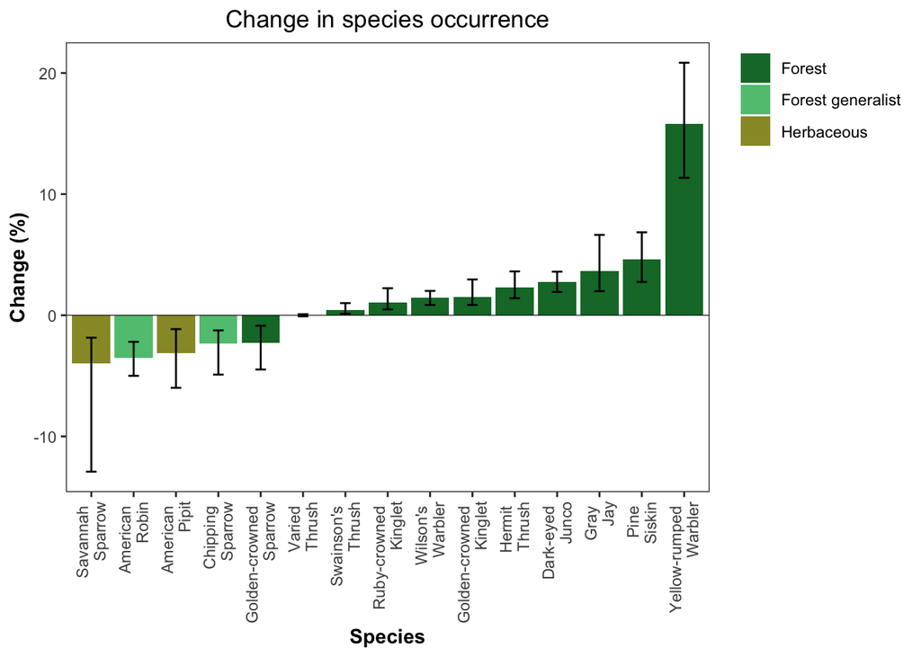

```r
plottitle <- ifelse(sensitivity == "", "Change in species occurrence",
                    ifelse(sensitivity == "lb", "Change in species occurrence - lower bound",
                           ifelse(sensitivity == "ub", "Change in species occurrence - upper bound")))

plot1 <- ggplot(data=df %>% filter(STUDY=="Current Study"), aes(x=NAMESEP, y=ESTIMATE, fill=BREEDING)) +
  theme_bw() +
  geom_bar(stat="identity",position=position_dodge(0.9)) +
  geom_errorbar(aes(ymax=CI_HIGH, ymin=CI_LOW) ,position=position_dodge(0.9),width=0.25) +
  scale_fill_manual("Legend", values = c("Forest" = rgb(19/256,119/256,51/256),
                                         "Herbaceous" = rgb(153/256,153/256,50/256),
                                         "Forest generalist" = rgb(95/256,196/256,128/256))) +
  labs(x="Species",y="Change (%)") +
  ggtitle(plottitle) +
  theme(plot.title = element_text(hjust = 0.5),
        axis.text  = element_text(),
        axis.text.x = element_text(angle=90, vjust=0.5, hjust=1),
        axis.title = element_text(face="bold"),
        text       = element_text(),
        panel.background = element_rect(fill="transparent", colour=NA),
        plot.background = element_rect(fill="transparent", colour=NA),
        panel.grid.minor = element_blank(),
        panel.grid.major = element_blank(),
        legend.title = element_blank(),
        legend.position.inside = c(0.01,0.99),
        legend.background = element_blank(),
        legend.justification = c("left","top"))+
  geom_hline(yintercept = 0, linewidth=0.2)

plot1
```

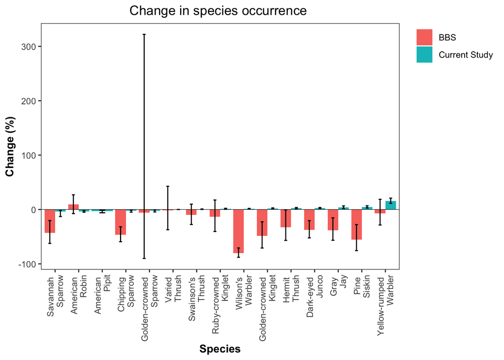

```r
plot2a <- ggplot(data=df, aes(x=NAMESEP, y=ESTIMATE, fill=STUDY)) +
  theme_bw() +
  geom_bar(stat="identity",position=position_dodge(0.9)) +
  geom_errorbar(aes(ymax=CI_HIGH, ymin=CI_LOW) ,position=position_dodge(0.9),width=0.25) +
  labs(x="Species",y="Change (%)") +
  ggtitle(paste("Change in species occurrence", sensitivity)) +
  theme(plot.title = element_text(hjust = 0.5),
        axis.text  = element_text(),
        axis.text.x = element_text(angle=90, vjust=0.5, hjust=1),
        axis.title = element_text(face="bold"),
        text       = element_text(),
        panel.background = element_rect(fill="transparent", colour=NA),
        plot.background = element_rect(fill="transparent", colour=NA),
        panel.grid.minor = element_blank(),
        panel.grid.major = element_blank(),
        legend.title = element_blank(),
        legend.position.inside = c(0.01,0.99),
        legend.background = element_blank(),
        legend.justification = c("left","top"))+
  geom_hline(yintercept = 0, linewidth=0.2)

plot2a
```

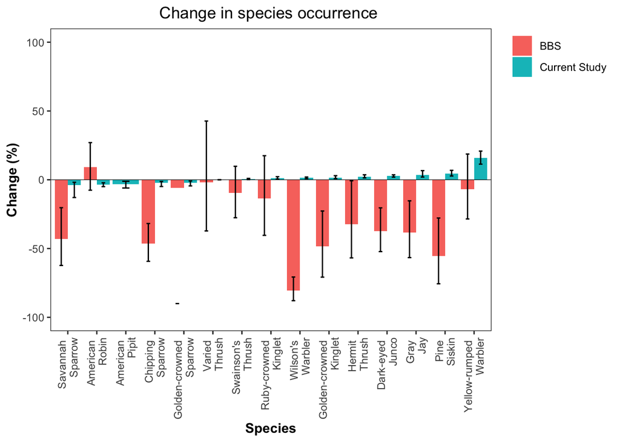

```r
plot2b <- ggplot(data=df, aes(x=NAMESEP, y=ESTIMATE, fill=STUDY)) +
  theme_bw() +
  geom_bar(stat="identity",position=position_dodge(0.9)) +
  geom_errorbar(aes(ymax=CI_HIGH, ymin=CI_LOW), position=position_dodge(0.9),width=0.25) +
  labs(x="Species",y="Change (%)") +
  ylim(c(-100,100)) +
  ggtitle(paste("Change in species occurrence", sensitivity)) +
  theme(plot.title = element_text(hjust = 0.5),
        axis.text  = element_text(),
        axis.text.x = element_text(angle=90, vjust=0.5, hjust=1),
        axis.title = element_text(face="bold"),
        text       = element_text(),
        panel.background = element_rect(fill="transparent", colour=NA),
        plot.background = element_rect(fill="transparent", colour=NA),
        panel.grid.minor = element_blank(),
        panel.grid.major = element_blank(),
        legend.title = element_blank(),
        legend.position.inside = c(0.01,0.99),
        legend.background = element_blank(),
        legend.justification = c("left","top"))+
  geom_hline(yintercept = 0, linewidth=0.2)

plot2b
```

We see relatively large differences in change estimates between our estimates and the Breeding Bird Survey. The Breeding Bird Survey changes span the years 1970-2022 for most species.

The most notable potential explanation is the fact that the BBS changes are for the entire Northern Rockies Bird Conservation Region (BCR), which is a very large area spanning the Columbia and Rocky mountain ranges in British Columbia and Alberta, whereas our study area is just a small fraction of the total BCR. Plus, the landscape change across the whole BCR - which includes industrial areas, urban areas, forestry, etc. - is likely higher than what has been observed in our highly protected area in the Willmore Wilderness Park over the same time period. Therefore our sample is not representative of the same population that the BBS conservation region covers.

## Save outputs

```r
ggsave(plot = plot1, file = paste0("./Plots/plot1_", sensitivity, ".png"),
       type = "cairo-png",  bg = "white",
       width = 20, height = 15, units = "cm", dpi = 300)
ggsave(plot = plot2a, file = paste0("./Plots/plot2a_", sensitivity, ".png"),
       type = "cairo-png",  bg = "white",
       width = 20, height = 15, units = "cm", dpi = 300)
ggsave(plot = plot2b, file = paste0("./Plots/plot2b_", sensitivity, ".png"),
       type = "cairo-png",  bg = "white",
       width = 20, height = 15, units = "cm", dpi = 300)
```